# Introduction to Survival Analysis

F.A. Barrios Instituto de Neurobiología UNAM

2025-10-15

```r
library(survival)
library(survminer)
library(car)
library(tidyverse)
```

## Introduction to Survival Analysis

Survival analysis is used to analyze data in which **the time until the event is of interest**. The **response variable** is the **time until that event** and is often called a failure time, survival time, or* **event time**. It is particularly useful in fields like medicine, engineering, and social sciences, where understanding the timing of events is crucial. The response, event time, is usually continuous, but survival analysis allows the response to be incompletely determined for some subjects then we say that the survival time is **censored**. When the real survival time is not known is classified as *type I censoring* in the case of loss to follow-up the terminating event is classified as **right censored**, when the end of the experiment mark the terminating event it is classified as *type II censoring*.  
There are several reasons for studying survival time using the specialized methods of survival analysis.  
1. Time to event can have an unusual distribution. Survival time is restricted to be positive so it has a skewed distribution and will never be normally distributed.  
2. The probability of surviving past a certain time is often more relevant than the expected survival time (and expected survival time may be difficult to estimate if the amount of censoring is large).  
3. A function used in survival analysis, the hazard function, helps one to understand the mechanism of the event.

### The Kaplan–Meier Procedure (intro from Daniel)

Also known as the *product-limit method* of estimating survival probabilities. Is used to assess results and identify predictors of survival, Martini et al. reviewed their total experience with primary malignant tumors of the sternum. They classified patients as having either low-grade (25 patients) or high-grade (14 patients) tumors. The event (status), time to event (months), and tumor grade for each patient are shown in the following table. We wish to compare the 5-year (60 months) survival rate of these two groups by means of the *Kaplan–Meier procedure*. For vital status are **dod** = dead of disease; **ned** = no evidence of disease; **dpo** = dead post operation and the tumor grade: L = low-grade; H = high-grade.

| Subject | Time (Months) | Vital Status | Tumor Grade | Subject | Time (Months) | Vital Status | Tumor Grade |
| --- | --- | --- | --- | --- | --- | --- | --- |
| 1 | 29 | dod | L | 21 | 155 | ned | L |
| 2 | 129 | ned | L | 22 | 102 | dod | L |
| 3 | 79 | dod | L | 23 | 34 | ned | L |
| 4 | 138 | ned | L | 24 | 109 | ned | L |
| 5 | 21 | dod | L | 25 | 15 | dod | L |
| 6 | 95 | ned | L | 26 | 122 | ned | H |
| 7 | 137 | ned | L | 27 | 27 | dod | H |
| 8 | 6 | ned | L | 28 | 6 | dod | H |
| 9 | 212 | dod | L | 29 | 7 | dod | H |
| 10 | 11 | dod | L | 30 | 2 | dod | H |
| 11 | 15 | dod | L | 31 | 9 | dod | H |
| 12 | 337 | ned | L | 32 | 17 | dod | H |
| 13 | 82 | ned | L | 33 | 16 | dod | H |
| 14 | 33 | dod | L | 34 | 23 | dod | H |
| 15 | 75 | ned | L | 35 | 9 | dod | H |
| 16 | 109 | ned | L | 36 | 12 | dod | H |
| 17 | 26 | ned | L | 37 | 4 | dod | H |
| 18 | 117 | ned | L | 38 | 0 | dpo | H |
| 19 | 8 | ned | L | 39 | 3 | dod | H |

Calculations for the Kaplan–Meier Procedure
We let:
$$\begin{array}{ll}
{\verb+Var+} & {\verb+Description+} \\
\hline
n = & {\verb+the number of subjects whose survival times are
available+} \\
p_1 = & {\verb+the proportion of subjects surviving at least the
first time period+} \\
p_2 = & {\verb+the proportion of subjects surviving the second
time period after having survived the first time period+} \\
p_3 = & {\verb+the proportion of subjects surviving the third time
period after having survived the second time period+} \\
p_k = & {\verb+the proportion of subjects surviving the kth time
period after having survived th (k-1)th time period+} \\
\hline
\end{array}$$

These proportions are used as estimates of the probability that the subject from the population represented by the sample will survive the periods $1,2,3, \dots, k$, respectively. The probabilities will be relabel $\hat{p}_1, \hat{p}_2, \hat{p}_3, \dots, \hat{p}_k$.
The probability of surviving the *t*th time period, $p_t$ at any time *t*, with $1 \leq t \leq k$ can be estimated as follows
$$\hat{p}_t = \frac{\verb+number of subjects surviving at least (t-1) time
periods who also survive the t period+}{\verb+number of subjects alive
at the end of time period (t-1)+}$$
The probability to surviving to time *t*, *S(t)*, is estimated by

$$\hat{S}(t) = \hat{p}_1 \times \hat{p}_2 \times \dots \times \hat{p}_t$$
Data arrangement and calculations for Kaplan-Meier procedure from the patients of different tumor grade.

$$\begin{array}{lccccc}
{\verb+Time (Months)+} & {\verb+Vital status (0,1)+} &
{\verb+At risk+} & {\verb+Remaining alive+} & {\verb+Survival
proportion+} & {\verb+Cumulative proportion+}\\
\hline
& & & {\verb+Patients with low-grade tumors+}
& & \\
6 & 0 & & & & \\
8 & 0 & & & & \\
11 & 1 & 23 & 22 & 22/23 = .95652 & .95652 \\
15 & 1 & & & & \\
15 & 1 & 22 & 20 & 20/22 = .90909 & .95652*.90909 =
.86956 \\
21 & 1 & 20 & 19 & 19/20 = .95000 & .95000*.86956 =
.82608 \\
26 & 0 & & & & \\
29 & 1 & 18 & 17 & 17/18 = .94444 & .94444*.82608 =
.780192 \\
33 & 1 & 17 & 16 & 16/17 = .94117 & .73429 \\
34 & 0 & & & & \\
75 & 0 & & & & \\
79 & 1 & 14 & 13 & 13/14 = .92857 & .68184 \\
82 & 0 & & & & \\
95 & 0 & & & & \\
102 & 1 & 11 & 10 & 10/11 = .90909 & .61986 \\
109 & 0 & & & & \\
109 & 0 & & & & \\
117 & 0 & & & & \\
127 & 0 & & & & \\
129 & 0 & & & & \\
137 & 0 & & & & \\
138 & 0 & & & & \\
155 & 0 & & & & \\
212 & 1 & 2 & 1 & 1/2 = .50000 & .30993 \\
337 & 0 & & & & \\
Total L & Dead & & & & \\
2201 & 9 & & & & & \\
& & & {\verb+Patients with high-grade tumors+}
& & \\
0 & 1 & 14 & 13 & 13/14 = .92857 & .92857 \\
2 & 1 & 13 & 12 & 12/13 = .92307 & .85714 \\
3 & 1 & 12 & 11 & 11/12 = .91666 & .78571 \\
4 & 1 & 11 & 10 & 10/11 = .90909 & .71428 \\
6 & 1 & 10 & 9 & 9/10 = .9000 & .64285 \\
7 & 1 & 9 & 8 & 8/9 = .8888 & .57142 \\
9 & 1 & & & & \\
9 & 1 & 8 & 6 & 6/8 = .7500 & .42857 \\
12 & 1 & 6 & 5 & 5/6 = .8333 & .35714 \\
16 & 1 & 5 & 4 & 4/5 = .8000 & .28571 \\
17 & 1 & 4 & 3 & 3/4 = .7500 & .21428 \\
23 & 1 & 3 & 2 & 2/3 = .6666 & .14285 \\
27 & 1 & 2 & 1 & 1/2 = .5000 & .07142 \\
122 & 0 & 1 & 0 & & \\
Total H & Dead & & & & \\
257 & 13 & & & & & \\
\hline
\end{array}$$

From this table we can easily estimate:  
The **Median survival time**, this is to locate the time in months at which the cumulative survival proportion is equal to $0.5$, for the low grade (LG) we can see from the table that it happens in the 212 months and for the high grade (HG) the 9 months.  
The **5-year (60 months) survival rate** we calculate LG: 0.7342 x 100 -> 73% and for HG: 0.07114 x 100 -> 7%.  
The **Mean survival time** for each group may be computed directly as the total months divided by the total subjects, $\bar{T}_{LG} = 2201 / 25 = 88.04$ months and $\bar{T}_{HG} = 257/14 = 18.35$ months.

### Right Censoring and examples

To illustrate the special characteristics of survival data, we consider a study of *6-mercaptopurine* (6-MP) as maintenance therapy for children in remission from *acute lymphoblastic leukemia (ALL)*. Forty-two (ALL) patients achieved remission from induction therapy, and were then randomized in equal numbers to 6-MP or placebo groups. The survival time studied was from randomization until relapse. At the time of the analysis, all 21 patients in the placebo group had relapsed, whereas only 9 of 21 patients in the 6-MP group had. One crucial characteristic of these survival times is that for the 12 patients in the 6-MP group who remained in remission at the time of the analysis, the exact time to relapse was unobserved; it was only known to exceed the follow-up time. For example, one patient had only been under observation for six weeks, so we only know that the relapse time is longer than that. Such a survival time is said to be *right-censored*.

Definition: A survival time is said to be right-censored at time *t* if it is only known to be greater than *t*, (not precisely determined).

```r
leuk <- read_csv("~/Dropbox/GitHub/Regression/DataRegressBook/Chap3/leuk.csv",
                 show_col_types = FALSE)
names(leuk)
```

```
[1] "time"  "cens"  "group"
```

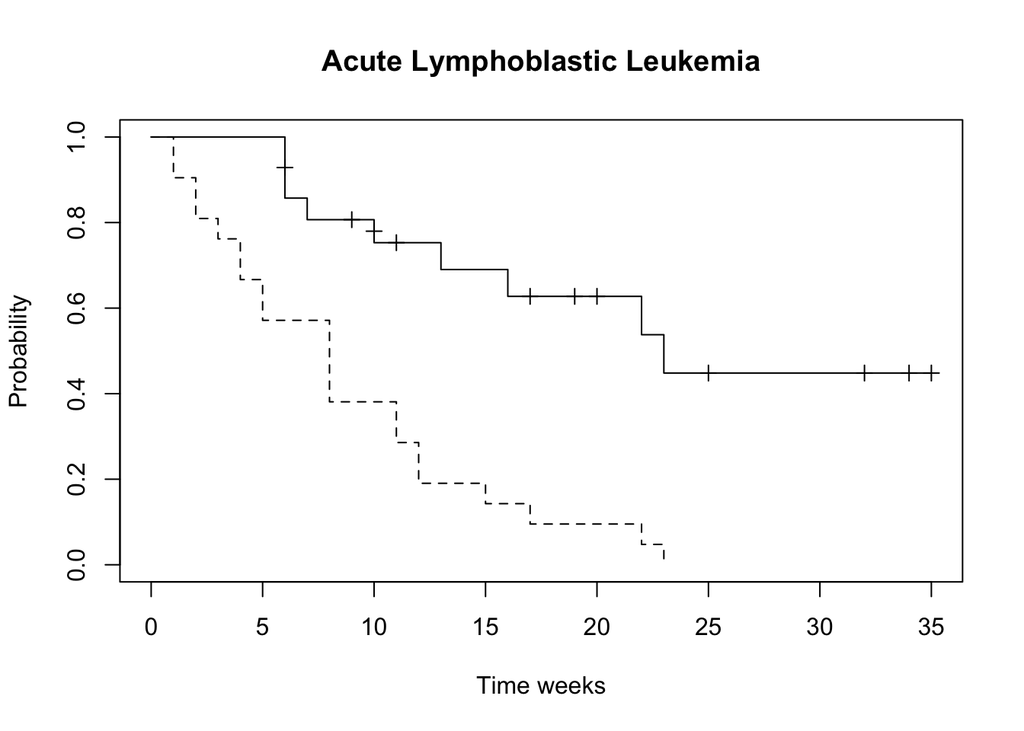

```r
plot(survfit(Surv(time, cens) ~ group, data = leuk), main = "Acute Lymphoblastic Leukemia",
     mark.time = TRUE,  lty = c(1,2), legend.text = c("Placebo", "6-MP"), legend.bty = "s",
     ylab = "Probability", xlab = "Time weeks")
```

```r
survdiff(Surv(time, cens) ~ group, data=leuk)
```

```
Call:
survdiff(formula = Surv(time, cens) ~ group, data = leuk)

               N Observed Expected (O-E)^2/E (O-E)^2/V
group=6 MP    21        9     19.3      5.46      16.8
group=Placebo 21       21     10.7      9.77      16.8

 Chisq= 16.8  on 1 degrees of freedom, p= 4e-05
```

Definition: The survival function at time *t*, denoted *S(t)* is the probability of being event-free at time *t*; equivalently, the probability that the survival time is greater than t.

### Interpretarion of Kaplan-Meier Curves

Plots of the Kaplan–Meier estimates of S(t), we can infer periods of high risk, when the survival curve descends rapidly, as well as periods of lower risk, when it remains relatively flat.

### Fitting a survival model

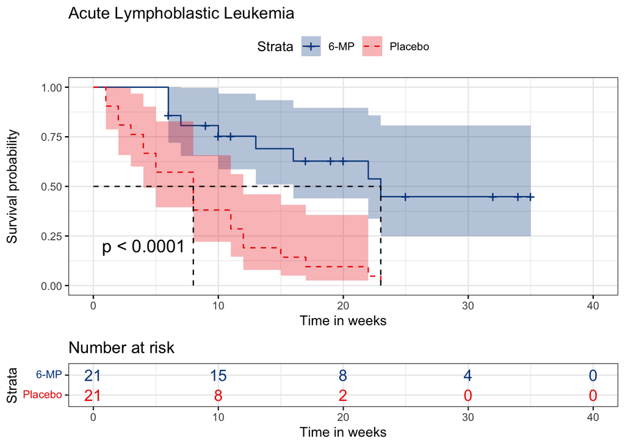

```r
fit <- survfit(Surv(time, cens) ~ group, data = leuk)
# ggsurvplot(fit, data = leuk, censor.shape="|", censor.size = 4, linetype = c(2, 1))

# With ggplot using
ggsurvplot(
  fit,
  data = leuk,
  size = 0.5,                 # change line size
  linetype = c("solid", "dashed"), # different line type
  palette  = c("lancet"), # color red, blue or custom palettes lancet
  title    = "Acute Lymphoblastic Leukemia", # plot main title
  xlab     = "Time in weeks",   # customize X axis label.
  conf.int = TRUE,          # Add confidence interval
  pval     = TRUE,          # Add p-value from log-rank test
  risk.table = TRUE,        # Add risk table
  risk.table.col = "strata", # Risk table color by groups
  legend.labs = c("6-MP", "Placebo"),    # Change legend labels
  risk.table.height = 0.25, # Useful to change when you have multiple groups
  surv.median.line  = "hv", # add the median survival pointer.
  ggtheme = theme_bw()      # Change ggplot2 theme
)
```

How is the data organized for these kind of problems?

```r
leuk$group
```

```
 [1] "6 MP"    "6 MP"    "6 MP"    "6 MP"    "6 MP"    "6 MP"    "6 MP"
 [8] "6 MP"    "6 MP"    "6 MP"    "6 MP"    "6 MP"    "6 MP"    "6 MP"
[15] "6 MP"    "6 MP"    "6 MP"    "6 MP"    "6 MP"    "6 MP"    "6 MP"
[22] "Placebo" "Placebo" "Placebo" "Placebo" "Placebo" "Placebo" "Placebo"
[29] "Placebo" "Placebo" "Placebo" "Placebo" "Placebo" "Placebo" "Placebo"
[36] "Placebo" "Placebo" "Placebo" "Placebo" "Placebo" "Placebo" "Placebo"
```

```r
leuk$time
```

```
 [1]  6  6  6  7 10 13 16 22 23  6  9 10 11 17 19 20 25 32 32 34 35  1  1  2  2
[26]  3  4  4  5  5  8  8  8  8 11 11 12 12 15 17 22 23
```

```r
leuk$cens
```

```
 [1] 1 1 1 1 1 1 1 1 1 0 0 0 0 0 0 0 0 0 0 0 0 1 1 1 1 1 1 1 1 1 1 1 1 1 1 1 1 1
[39] 1 1 1 1
```

### The Cox Proportional Hazards Model.

The Cox proportional hazards model is a widely used statistical technique in survival analysis that assesses the effect of several variables on the time until an event occurs, such as death or failure. Developed by David Cox in 1972, this semi-parametric model allows researchers to examine the relationship between multiple predictors and the hazard rate, which is the risk of the event occurring at a particular time.

Hazard Function The model expresses the hazard function $h(t)$ as:
$$h(t) = h_0(t) e^{(\beta_1 x_1 + \beta_2 x_2 + \dots + \beta_n x_n)}$$
where:
$h_0(t)$ is the baseline hazard function, representing the hazard when all covariates are zero.
$\beta_i$ are the coefficients corresponding to each covariate $x_i$.
The term $\exp({\beta_i})$ represents the **hazard ratio (HR)**, indicating how each covariate affects the hazard.
Interpretation of Hazard Ratios
HR = 1: No effect on the hazard.
HR < 1: Indicates a reduction in hazard (better survival).
HR > 1: Indicates an increase in hazard (worse survival).
For example, if a covariate has an HR of 1.5, it suggests that for each unit increase in that covariate, the risk of the event occurring increases by 50%.
The baseline hazard $h_0(t)$ is crucial for interpreting results from a Cox regression analysis. It helps in understanding how individual covariate affect the risk of an event relative to this baseline. For instance, if a covariate has a significant positive coefficient, it indicates that individuals with higher values of that covariate have a higher hazard compared to those at the baseline level.
The baseline hazard in the Cox proportional hazards model is significant because it provides a reference point for understanding how various predictors influence survival times. Its flexibility and lack of strict parametric assumptions make it a powerful tool in survival analysis, allowing researchers to derive meaningful insights from complex datasets without imposing unnecessary constraints on the underlying hazard function.

### Recidivism (the tendency of a convicted criminal to reoffend)

The Rossi data set in the CarData. Is a study made by Allison of recidivism of 432 male prisoners, who were observed for a year after being released from prison. The following variables are included in the data:  
*`week`: week of the first arrest after release, or censoring time.*  
`arrest`: the event indicator, equal to 1 for those arrested during the period of the study and 0 for those who were not arrested.  
*`fin`: a factor, levels yes or no in the individual received finantial aid after release from prison.*  
`age`: in years at the time of release.  
*`race`: a factor with levels “black” and “other”.*  
`wexp`: a factor “yes” if the individual had full-time work experience prior to incarceration or “no”.  
*`mar`: a factor with levels “married” if the individual was married at the time of release and “not married” if he was not.*  
`paro`: a factor coded “yes” if the individual was released on parole and “no” if he was not.  
*`prio`: number of prior convictions.*  
`educ`: education, categorical variable coded numerically, with codes 2 (grade 6 or less), 3 (grades 6 through 9), 4 (grades 10 and 11), 5 (grade 12), or 6(some post-secondary).  
*`emp1-emp52`: factors coded “yes” if the individual was employed in the corresponding week of the study.

```r
# Cox proportional-hazards regression
data("Rossi", package = "carData")
args(coxph)
```

```
function (formula, data, weights, subset, na.action, init, control,
    ties = c("efron", "breslow", "exact"), singular.ok = TRUE,
    robust, model = FALSE, x = FALSE, y = TRUE, tt, method = ties,
    id, cluster, istate, statedata, nocenter = c(-1, 0, 1), ...)
NULL
```

```r
#

# Cox model and estimation of model tests
mod.Recidivism <- coxph(Surv(week, arrest) ~ fin + age + race + wexp + mar + paro + prio, data = Rossi)
summary(mod.Recidivism)
```

```
Call:
coxph(formula = Surv(week, arrest) ~ fin + age + race + wexp +
    mar + paro + prio, data = Rossi)

  n= 432, number of events= 114

                   coef exp(coef) se(coef)      z Pr(>|z|)
finyes         -0.37942   0.68426  0.19138 -1.983  0.04742 *
age            -0.05744   0.94418  0.02200 -2.611  0.00903 **
raceother      -0.31390   0.73059  0.30799 -1.019  0.30812
wexpyes        -0.14980   0.86088  0.21222 -0.706  0.48029
marnot married  0.43370   1.54296  0.38187  1.136  0.25606
paroyes        -0.08487   0.91863  0.19576 -0.434  0.66461
prio            0.09150   1.09581  0.02865  3.194  0.00140 **
---
Signif. codes:  0 '***' 0.001 '**' 0.01 '*' 0.05 '.' 0.1 ' ' 1

               exp(coef) exp(-coef) lower .95 upper .95
finyes            0.6843     1.4614    0.4702    0.9957
age               0.9442     1.0591    0.9043    0.9858
raceother         0.7306     1.3688    0.3995    1.3361
wexpyes           0.8609     1.1616    0.5679    1.3049
marnot married    1.5430     0.6481    0.7300    3.2614
paroyes           0.9186     1.0886    0.6259    1.3482
prio              1.0958     0.9126    1.0360    1.1591

Concordance= 0.64  (se = 0.027 )
Likelihood ratio test= 33.27  on 7 df,   p=2e-05
Wald test            = 32.11  on 7 df,   p=4e-05
Score (logrank) test = 33.53  on 7 df,   p=2e-05
```

The z column shows the ratio of each regression coefficient to its standard error, a Wald statistic to estimate the significance of the coefficient.

The exponential coefficients (second column) are the multiplicative effect in the hazard. For example, keeping all the predictors constant, but age, an additional year of age reduces the weekly hazard of arrest by a factor of 0.9442 on average (a 5.6 %). Similarly, each prior conviction increases the hazard by a factor of 1.096 (a 9.6%).

The likelihood-ratio, Wald and score chi-square statistics, at the bottom are asymptotically equivalent tests of the omnibus null hypothesis the all the $\beta$s are zero. In this case the omnibus null hypothesis is rejected.

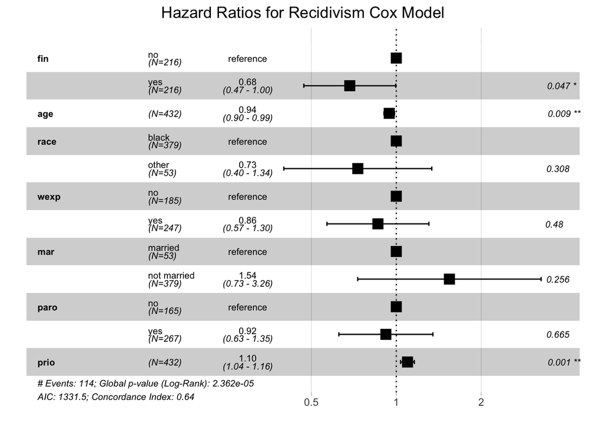

```r
ggforest(mod.Recidivism, data= Rossi, main = "Hazard Ratios for Recidivism Cox Model")
```

the forest plot helps to interpret the Hazard Ratios comparing to the reference (1) and the significance of the coefficient for that predictor.

### The Anova function (car)

The Anova function of car package has a method for “coxph” objects, by default estimates Type-II likelihood-ratio test for the terms of the Cox model

```r
Anova(mod.Recidivism)
```

```
Analysis of Deviance Table (Type II tests)
     LR Chisq Df Pr(>Chisq)
fin    3.9862  1   0.045874 *
age    7.9880  1   0.004709 **
race   1.1252  1   0.288812
wexp   0.5003  1   0.479352
mar    1.4312  1   0.231572
paro   0.1870  1   0.665450
prio   8.9766  1   0.002735 **
---
Signif. codes:  0 '***' 0.001 '**' 0.01 '*' 0.05 '.' 0.1 ' ' 1
```

```r
S(mod.Recidivism)
```

```
Call:
coxph(formula = Surv(week, arrest) ~ fin + age + race + wexp +
    mar + paro + prio, data = Rossi)

  n= 432, number of events= 114

                   coef exp(coef) se(coef)      z Pr(>|z|)
finyes         -0.37942   0.68426  0.19138 -1.983  0.04742 *
age            -0.05744   0.94418  0.02200 -2.611  0.00903 **
raceother      -0.31390   0.73059  0.30799 -1.019  0.30812
wexpyes        -0.14980   0.86088  0.21222 -0.706  0.48029
marnot married  0.43370   1.54296  0.38187  1.136  0.25606
paroyes        -0.08487   0.91863  0.19576 -0.434  0.66461
prio            0.09150   1.09581  0.02865  3.194  0.00140 **
---
Signif. codes:  0 '***' 0.001 '**' 0.01 '*' 0.05 '.' 0.1 ' ' 1

               exp(coef) exp(-coef) lower .95 upper .95
finyes            0.6843     1.4614    0.4702    0.9957
age               0.9442     1.0591    0.9043    0.9858
raceother         0.7306     1.3688    0.3995    1.3361
wexpyes           0.8609     1.1616    0.5679    1.3049
marnot married    1.5430     0.6481    0.7300    3.2614
paroyes           0.9186     1.0886    0.6259    1.3482
prio              1.0958     0.9126    1.0360    1.1591

Concordance= 0.64  (se = 0.027 )
Likelihood ratio test= 33.27  on 7 df,   p=2e-05
Wald test            = 32.11  on 7 df,   p=4e-05
Score (logrank) test = 33.53  on 7 df,   p=2e-05
```

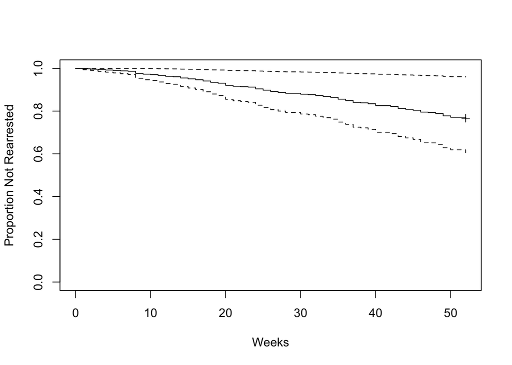

```r
# Plots of the Cox model
plot(survfit(mod.Recidivism), mark.time = TRUE, xlab="Weeks", ylab="Proportion Not Rearrested")
```

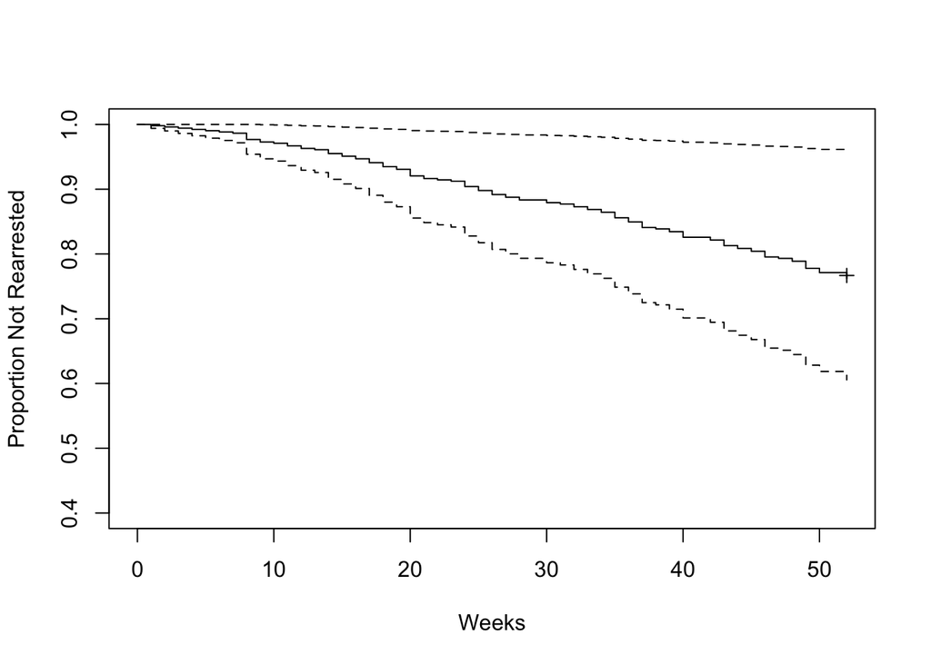

```r
# now with better scale
plot(survfit(mod.Recidivism), mark.time = TRUE, ylim = c(0.4, 1), xlab="Weeks", ylab="Proportion Not Rearrested")
```

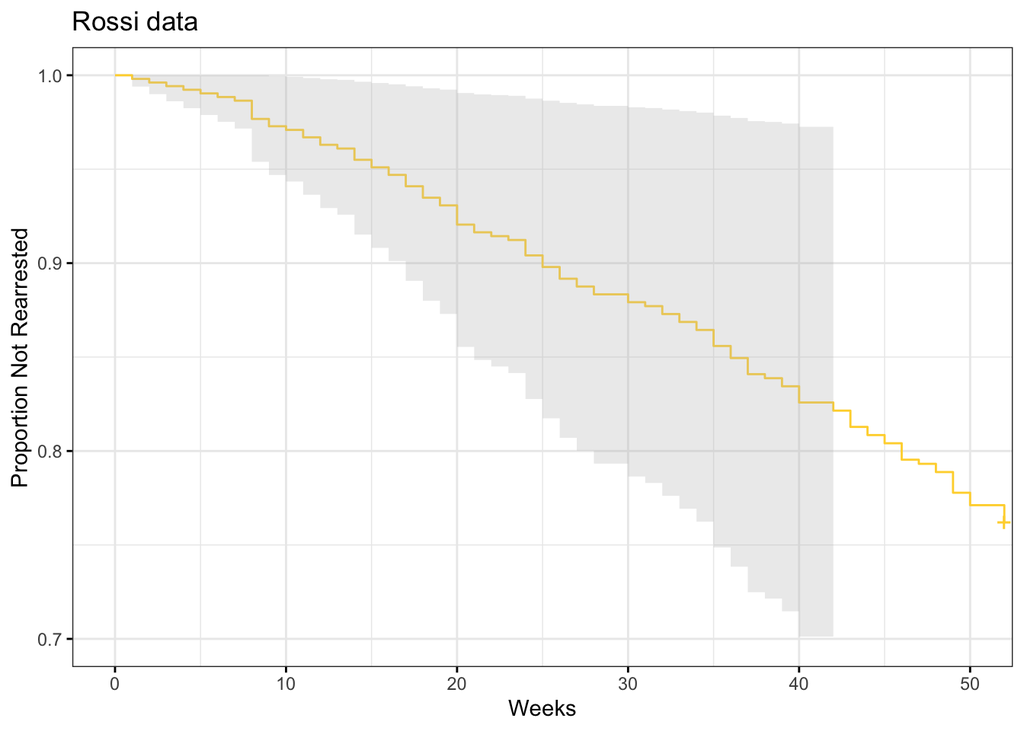

```r
# With ggplot using ggsurvplot
#
ggsurvplot(
survfit(mod.Recidivism),
data = Rossi,
size = 0.5,                      # change line size
linetype = c("solid","dashed"), # different line type
palette = "simpsons",              # color palette
title   = "Rossi data",          # plot main title
xlab = "Weeks",                  # customize X axis label.
ylab = "Proportion Not Rearrested", # customize Y axis label
ylim = c(0.7, 1),             # customize Y limits
conf.int = TRUE,             # Add confidence interval
pval = FALSE,                 # Add p-value from log-rank test
risk.table = FALSE,           # Add risk table
risk.table.col = "strata",   # Risk table color by groups
surv.median.line = "none",
legend = "none",
risk.table.height = 0.25,    # Useful to change when you have multiple groups
ggtheme = theme_bw()         # Change ggplot2 theme
)
```

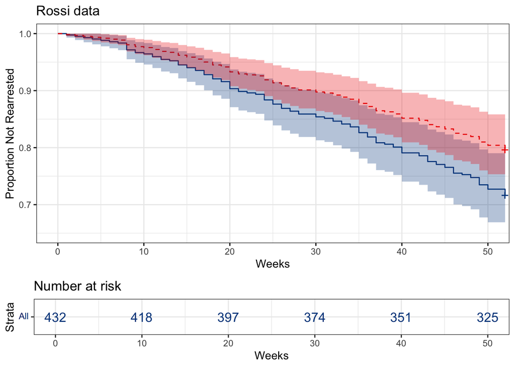

```r
# To study the fin help variable
Rossi.fin <- with (Rossi, data.frame(fin=c(0, 1),
                  age=rep(mean(age), 2),
                  race=rep(mean(race == "other"), 2),
                  wexp=rep(mean(wexp == "yes"), 2),
                  mar=rep(mean(mar == "not married"), 2),
                  paro=rep(mean(paro == "yes"), 2),
                  prio=rep(mean(prio), 2)) )

# plot(survfit(mod.Recidivism, newdata=Rossi.fin), conf.int=TRUE,
# lty=c(1,2), ylim=c(0.6, 1), xlab="Weeks",
# ylab="Proportion Not Rearrested")
# legend("bottomleft", legend=c("fin = no", "fin = yes"), lty=c(1, 2), insert=0.02)

ggsurvplot(
  survfit(mod.Recidivism, newdata=Rossi.fin),
  data = Rossi.fin,
  size = 0.5,                     # change line size
  linetype = c("solid","dashed"), # different line type
  palette = "lancet",             # color palette
  title   = "Rossi data",         # plot main title
  xlab = "Weeks",                 # customize X axis label.
  ylab = "Proportion Not Rearrested", # customize Y axis label
  ylim = c(0.65, 1),           # customize Y limits
  conf.int = TRUE,            # Add confidence interval
  risk.table = TRUE,          # show risk table
  pval = TRUE,                # Add p-value from log-rank test
  risk.table.y.text.col = TRUE,         # Add risk table
  risk.table.col = "strata",  # Risk table color by groups
  surv.median.line = "none",
  legend = "none",
  risk.table.height = 0.25,   # Useful to change when you have multiple groups
  ggtheme = theme_bw()        # Change ggplot2 theme
  )
```